# Rodgers_Assignment2

Mary E. Rodgers

2023-04-07

# **Introduction**

Previous measures of child linguistic growth from transcripts have used measures such as mean length of utterance (MLU) and total number of words (TNW; Hampton et al., 2017; Roberts et al., 2012). More recent research has suggested that measures such as the number of unique verbs are a better measure of linguistic growth (Hadley, 2020; Hadley et al., 2018).

## *Research Questions*

Our primary research question is: 1) What linguistic metrics predict the number of verbs children use?

This research question will be answered through linear regression, using both a statistical and machine learning approach.

## *Data*

The metrics of interest include:

- Y, a label indicating 0 for TD children and 1 for SLI diagnosed children.
- age, the age of the child in months.
- Child_TNW, the total number of words said by the child in the transcript.
- child_TNS, the total number of sentences said by the child in the transcript.
- examiner_TNW, the total number of words spoken by the examiner.
- fillers, the number of filler words (e.g., um, uh) said by the child in the transcript.
- mlu_words, the mean length of the words said by the child in the transcript.
- mlu_morphemes, the mean length of sentences said by the child in the transcript.
- verb_utt, the number of utterances consisting of verbs said by the child in the transcript.
- articles, the number of articles (i.e., a, an, the) said by the child in the transcript.
- n_v, the number of verbs said by the child in the transcript.
- n_aux, the number of auxillary verbs said by the child in the transcript.

Source: https://www.kaggle.com/datasets/dgokeeffe/specific-language-impairment

## *Git Hub*

https://github.com/Mary-E-Rodgers/ML_RegressionModel.git

# **Methods**

## *1. Data wrangling*

### Preparing R

First we connected to the CRAN mirror.

```r
options(repos=c(CRAN="https://mirrors.nics.utk.edu/cran/"))
```

Then the global environment was cleared to ensure a clean work space.

```r
rm(list=ls(all=TRUE))
```

Alternatively, you can select the ‘sweep’ button in the global environment

The necessary R packages can then be pulled in.

*If an error occured, we could make sure the packages are installed by using install.packages(“packagename”) where the name of the package goes in the quotation marks

```r
library(tidyverse) # this package contains tools for data cleaning and organization
```

```r
library(ggplot2) # this is used for data visualization
library(dplyr) # this contains tools for data manipulation
library(caret) # this contains functions for classification and regression raining
library(car) # this is for variance inflation factor (VIF)
library(corrplot) # this package is for visualizing your correlation
library(relaimpo) # this is for variable importance
library(PerformanceAnalytics) # this contains tools for performance and risk analysis
library(glmnet) # this is for modeling generalized linear models
library(psych) # this is for descriptive statistics
library(relaimpo) # this is for calculating metrics for linear modeling
```

### Importing your Data

The .csv data set was downloaded and saved with the R software so that it imported properly.

Source: [Kaggle Data Set] (https://www.kaggle.com/datasets/dgokeeffe/specific-language-impairment)

A tibble was created from the .csv file, named “all_data_R_tib”.

```r
all_data_R_tib <- read_csv("all_data_R.csv")
```

### Cleaning your Data

Messages and warnings about the code were enabled, and the tibble was called in. This tibble contained all of variables from the original .csv file that was downloaded. The variable of interests were selected using dplyr, and the structure was displayed.

```r
# enables messages and warnings about your code
all_data_R_tib <- read_csv("all_data_R.csv") # creates your tibble from the csv
all_data_R_tib <- all_data_R_tib %>%
  dplyr::select (n_v, age, child_TNW, child_TNS, examiner_TNW, fillers, mlu_words, mlu_morphemes, verb_utt, articles, n_aux) # calls in the columns you want, removed group ()
str(all_data_R_tib) # this displays the structure of R objects, in this case, our clean tibble
```

```
## tibble [1,163 × 11] (S3: tbl_df/tbl/data.frame)
##  $ n_v          : num [1:1163] 0 0 0 1 0 0 0 1 0 0 ...
##  $ age          : num [1:1163] 165 172 160 184 176 178 180 163 162 176 ...
##  $ child_TNW    : num [1:1163] 287 368 266 405 300 224 385 571 355 247 ...
##  $ child_TNS    : num [1:1163] 36 42 26 40 35 31 27 55 34 29 ...
##  $ examiner_TNW : num [1:1163] 4 27 2 21 20 26 21 15 2 3 ...
##  $ fillers      : num [1:1163] 8 0 5 2 3 0 10 9 0 1 ...
##  $ mlu_words    : num [1:1163] 7.06 8.68 9.8 8.68 8.26 ...
##  $ mlu_morphemes: num [1:1163] 8 9.68 11.12 9.72 9.31 ...
##  $ verb_utt     : num [1:1163] 1 1.2 1.6 1.4 1.31 ...
##  $ articles     : num [1:1163] 0 0 1 0 1 1 0 1 5 0 ...
##  $ n_aux        : num [1:1163] 2 4 1 0 1 0 0 3 1 0 ...
```

### Scaling the data

The data in the tibble were scaled.

```r
all_data_R_tib_sc <- all_data_R_tib %>%
  na.omit() %>%
  mutate_at(c(1:11), ~(scale(.) %>% as.vector))

str(all_data_R_tib_sc)
```

```
## tibble [1,163 × 11] (S3: tbl_df/tbl/data.frame)
##  $ n_v          : num [1:1163] -0.642 -0.642 -0.642 -0.157 -0.642 ...
##  $ age          : num [1:1163] 2 2.22 1.84 2.59 2.34 ...
##  $ child_TNW    : num [1:1163] -0.561 -0.2272 -0.6475 -0.0748 -0.5074 ...
##  $ child_TNS    : num [1:1163] -0.523 -0.305 -0.886 -0.378 -0.56 ...
##  $ examiner_TNW : num [1:1163] -0.306 0.444 -0.371 0.248 0.216 ...
##  $ fillers      : num [1:1163] 0.11 -0.795 -0.23 -0.569 -0.456 ...
##  $ mlu_words    : num [1:1163] -0.31 0.685 1.377 0.685 0.428 ...
##  $ mlu_morphemes: num [1:1163] -0.265 0.638 1.417 0.665 0.443 ...
##  $ verb_utt     : num [1:1163] -1.2785 -0.6141 0.7657 0.0843 -0.2087 ...
##  $ articles     : num [1:1163] -0.615 -0.615 -0.589 -0.615 -0.589 ...
##  $ n_aux        : num [1:1163] 0.148 0.794 -0.175 -0.498 -0.175 ...
```

#### Visually checking the data

The tibble was visually checked.

```r
print(all_data_R_tib_sc)
```

```
## # A tibble: 1,163 × 11
##       n_v   age child_…¹ child…² exami…³ fillers mlu_w…⁴ mlu_m…⁵ verb_…⁶ artic…⁷
##     <dbl> <dbl>    <dbl>   <dbl>   <dbl>   <dbl>   <dbl>   <dbl>   <dbl>   <dbl>
##  1 -0.642  2.00  -0.561   -0.523 -0.306    0.110  -0.310  -0.265 -1.28    -0.615
##  2 -0.642  2.22  -0.227   -0.305  0.444   -0.795   0.685   0.638 -0.614   -0.615
##  3 -0.642  1.84  -0.648   -0.886 -0.371   -0.230   1.38    1.42   0.766   -0.589
##  4 -0.157  2.59  -0.0748  -0.378  0.248   -0.569   0.685   0.665  0.0843  -0.615
##  5 -0.642  2.34  -0.507   -0.560  0.216   -0.456   0.428   0.443 -0.209   -0.589
##  6 -0.642  2.40  -0.821   -0.705  0.411   -0.795  -0.385  -0.440 -0.948   -0.589
##  7 -0.642  2.47  -0.157   -0.850  0.248    0.336   3.62    3.75   2.13    -0.615
##  8 -0.157  1.94   0.609    0.167  0.0527   0.223   1.32    1.32  -0.658   -0.589
##  9 -0.642  1.90  -0.281   -0.596 -0.371   -0.795   0.795   0.718  0.224   -0.485
## 10 -0.642  2.34  -0.726   -0.778 -0.338   -0.682   0.482   0.572 -0.692   -0.615
## # … with 1,153 more rows, 1 more variable: n_aux <dbl>, and abbreviated
## #   variable names ¹child_TNW, ²child_TNS, ³examiner_TNW, ⁴mlu_words,
## #   ⁵mlu_morphemes, ⁶verb_utt, ⁷articles
```

## *2. Checking for multi-collinearity*

### *Correlation*

#### Correlations in the entire tibble

A correlation was run on the entire tibble.

```r
cor(all_data_R_tib_sc) # this creates a correlation between your entire tibble
```

```
##                       n_v         age  child_TNW   child_TNS examiner_TNW
## n_v            1.00000000 -0.20706544  0.5215179  0.58163898  -0.02540869
## age           -0.20706544  1.00000000 -0.0492162 -0.20583881  -0.17034275
## child_TNW      0.52151794 -0.04921620  1.0000000  0.92681218  -0.15989840
## child_TNS      0.58163898 -0.20583881  0.9268122  1.00000000  -0.04658182
## examiner_TNW  -0.02540869 -0.17034275 -0.1598984 -0.04658182   1.00000000
## fillers        0.13732851 -0.06442492  0.2723414  0.19967106   0.02398242
## mlu_words     -0.08916668  0.55459574  0.2715630 -0.03361113  -0.33723797
## mlu_morphemes -0.13037155  0.56526995  0.2401329 -0.06783671  -0.32475503
## verb_utt      -0.12880296  0.40257988  0.2061951 -0.06045488  -0.31824339
## articles       0.56893748 -0.24137027  0.6752945  0.71960014  -0.13967640
## n_aux          0.37336385 -0.07389549  0.4780298  0.48495859  -0.08136342
##                   fillers   mlu_words mlu_morphemes    verb_utt    articles
## n_v            0.13732851 -0.08916668  -0.130371554 -0.12880296  0.56893748
## age           -0.06442492  0.55459574   0.565269948  0.40257988 -0.24137027
## child_TNW      0.27234138  0.27156301   0.240132899  0.20619509  0.67529447
## child_TNS      0.19967106 -0.03361113  -0.067836707 -0.06045488  0.71960014
## examiner_TNW   0.02398242 -0.33723797  -0.324755027 -0.31824339 -0.13967640
## fillers        1.00000000  0.04603144   0.047321826  0.03156350  0.06806747
## mlu_words      0.04603144  1.00000000   0.992816771  0.83525833 -0.03577672
## mlu_morphemes  0.04732183  0.99281677   1.000000000  0.83772850 -0.07641448
## verb_utt       0.03156350  0.83525833   0.837728498  1.00000000 -0.14668610
## articles       0.06806747 -0.03577672  -0.076414477 -0.14668610  1.00000000
## n_aux          0.09404062  0.02056392   0.005956738 -0.09034139  0.60098703
##                      n_aux
## n_v            0.373363849
## age           -0.073895486
## child_TNW      0.478029801
## child_TNS      0.484958590
## examiner_TNW  -0.081363424
## fillers        0.094040618
## mlu_words      0.020563922
## mlu_morphemes  0.005956738
## verb_utt      -0.090341389
## articles       0.600987034
## n_aux          1.000000000
```

#### Visualizing the correlations in the entire tibble

A correlation matrix of the entire tibble was created.

```r
cor_matrix <- abs(cor(all_data_R_tib_sc))
```

The correlation matrix of the entire tibble was visualized.

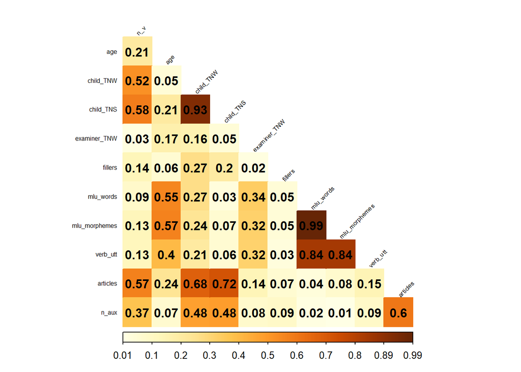

```r
corrplot(cor_matrix,
         type="lower", #put color strength on bottom
         tl.pos = "ld", #Character or logical, position of text labels, 'ld'(default if type=='lower') means left and diagonal,
         tl.cex = 0.5, #Numeric, for the size of text label (variable names).
         method="color",
         addCoef.col="black",
         diag=FALSE,
         tl.col="black", #The color of text label.
         tl.srt=45, #Numeric, for text label string rotation in degrees, see text
         is.corr = FALSE, #if you include correlation matrix
         #order = "hclust", #order results by strength
         #col=gray.colors(100), #in case you want it in gray...
         number.digits = 2) #number of digits after decimal
```

### Check for multi-collinearity

Using a statistical approach, multi-collinearity was checked by looking for correlations of the entire tibble and identifying anything with a correlation of 0.7 or above. Child TNS is correlated with Child TNW at 0.93. Child TNS is also correlated with articles at 0.72. Due to this, child TNS was removed from the model and run again.

```r
model2_tib <- read_csv("all_data_R.csv") # creating the new tibble
model2_tib <- model2_tib %>% #selecting the same variables but without child TNS
  dplyr::select (n_v, age, child_TNW, examiner_TNW, fillers, mlu_words, mlu_morphemes, verb_utt, articles, n_aux)

model2_tib_sc <- model2_tib %>% # scaling the data again
  na.omit() %>%
  mutate_at(c(1:10), ~(scale(.) %>% as.vector))

cor(model2_tib_sc) #running the correlation again
```

```
##                       n_v         age  child_TNW examiner_TNW     fillers
## n_v            1.00000000 -0.20706544  0.5215179  -0.02540869  0.13732851
## age           -0.20706544  1.00000000 -0.0492162  -0.17034275 -0.06442492
## child_TNW      0.52151794 -0.04921620  1.0000000  -0.15989840  0.27234138
## examiner_TNW  -0.02540869 -0.17034275 -0.1598984   1.00000000  0.02398242
## fillers        0.13732851 -0.06442492  0.2723414   0.02398242  1.00000000
## mlu_words     -0.08916668  0.55459574  0.2715630  -0.33723797  0.04603144
## mlu_morphemes -0.13037155  0.56526995  0.2401329  -0.32475503  0.04732183
## verb_utt      -0.12880296  0.40257988  0.2061951  -0.31824339  0.03156350
## articles       0.56893748 -0.24137027  0.6752945  -0.13967640  0.06806747
## n_aux          0.37336385 -0.07389549  0.4780298  -0.08136342  0.09404062
##                 mlu_words mlu_morphemes    verb_utt    articles        n_aux
## n_v           -0.08916668  -0.130371554 -0.12880296  0.56893748  0.373363849
## age            0.55459574   0.565269948  0.40257988 -0.24137027 -0.073895486
## child_TNW      0.27156301   0.240132899  0.20619509  0.67529447  0.478029801
## examiner_TNW  -0.33723797  -0.324755027 -0.31824339 -0.13967640 -0.081363424
## fillers        0.04603144   0.047321826  0.03156350  0.06806747  0.094040618
## mlu_words      1.00000000   0.992816771  0.83525833 -0.03577672  0.020563922
## mlu_morphemes  0.99281677   1.000000000  0.83772850 -0.07641448  0.005956738
## verb_utt       0.83525833   0.837728498  1.00000000 -0.14668610 -0.090341389
## articles      -0.03577672  -0.076414477 -0.14668610  1.00000000  0.600987034
## n_aux          0.02056392   0.005956738 -0.09034139  0.60098703  1.000000000
```

The mlu of morphemes is correlated with the mlu of words at 0.99 and with utterances with a verb at 0.84, so the model is run again without mlu of morphemes.

```r
model3_tib <- read_csv("all_data_R.csv")
model3_tib <- model3_tib %>% #selecting the same variables but without mlu of morphemes.
  dplyr::select (n_v, age, child_TNW, examiner_TNW, fillers, mlu_words, verb_utt, articles, n_aux)

model3_tib_sc <- model3_tib %>%
  na.omit() %>%
  mutate_at(c(1:9), ~(scale(.) %>% as.vector))

cor(model3_tib_sc)
```

```
##                      n_v         age  child_TNW examiner_TNW     fillers
## n_v           1.00000000 -0.20706544  0.5215179  -0.02540869  0.13732851
## age          -0.20706544  1.00000000 -0.0492162  -0.17034275 -0.06442492
## child_TNW     0.52151794 -0.04921620  1.0000000  -0.15989840  0.27234138
## examiner_TNW -0.02540869 -0.17034275 -0.1598984   1.00000000  0.02398242
## fillers       0.13732851 -0.06442492  0.2723414   0.02398242  1.00000000
## mlu_words    -0.08916668  0.55459574  0.2715630  -0.33723797  0.04603144
## verb_utt     -0.12880296  0.40257988  0.2061951  -0.31824339  0.03156350
## articles      0.56893748 -0.24137027  0.6752945  -0.13967640  0.06806747
## n_aux         0.37336385 -0.07389549  0.4780298  -0.08136342  0.09404062
##                mlu_words    verb_utt    articles       n_aux
## n_v          -0.08916668 -0.12880296  0.56893748  0.37336385
## age           0.55459574  0.40257988 -0.24137027 -0.07389549
## child_TNW     0.27156301  0.20619509  0.67529447  0.47802980
## examiner_TNW -0.33723797 -0.31824339 -0.13967640 -0.08136342
## fillers       0.04603144  0.03156350  0.06806747  0.09404062
## mlu_words     1.00000000  0.83525833 -0.03577672  0.02056392
## verb_utt      0.83525833  1.00000000 -0.14668610 -0.09034139
## articles     -0.03577672 -0.14668610  1.00000000  0.60098703
## n_aux         0.02056392 -0.09034139  0.60098703  1.00000000
```

The mlu of words was correlated with utterances containing a verb at 0.84, so the model is run again without mlu of words.

```r
model4_tib <- read_csv("all_data_R.csv")
model4_tib <- model4_tib %>% #selecting the same variables but without mlu of words.
  dplyr::select (n_v, age, child_TNW, examiner_TNW, fillers, verb_utt, articles, n_aux)

model4_tib_sc <- model4_tib %>%
  na.omit() %>%
  mutate_at(c(1:8), ~(scale(.) %>% as.vector))

cor(model4_tib_sc)
```

```
##                      n_v         age  child_TNW examiner_TNW     fillers
## n_v           1.00000000 -0.20706544  0.5215179  -0.02540869  0.13732851
## age          -0.20706544  1.00000000 -0.0492162  -0.17034275 -0.06442492
## child_TNW     0.52151794 -0.04921620  1.0000000  -0.15989840  0.27234138
## examiner_TNW -0.02540869 -0.17034275 -0.1598984   1.00000000  0.02398242
## fillers       0.13732851 -0.06442492  0.2723414   0.02398242  1.00000000
## verb_utt     -0.12880296  0.40257988  0.2061951  -0.31824339  0.03156350
## articles      0.56893748 -0.24137027  0.6752945  -0.13967640  0.06806747
## n_aux         0.37336385 -0.07389549  0.4780298  -0.08136342  0.09404062
##                 verb_utt    articles       n_aux
## n_v          -0.12880296  0.56893748  0.37336385
## age           0.40257988 -0.24137027 -0.07389549
## child_TNW     0.20619509  0.67529447  0.47802980
## examiner_TNW -0.31824339 -0.13967640 -0.08136342
## fillers       0.03156350  0.06806747  0.09404062
## verb_utt      1.00000000 -0.14668610 -0.09034139
## articles     -0.14668610  1.00000000  0.60098703
## n_aux        -0.09034139  0.60098703  1.00000000
```

Model four does not contain any predictors correlating with each other above 0.7, indicating that multi-collinearity is no longer present.

#### Visualizing the new model

A correlation matrix of model four was created.

```r
cor_matrix2 <- abs(cor(model4_tib_sc))
```

The correlation matrix of model four was visualized to assist in verifying no correlations over 0.7 are present.

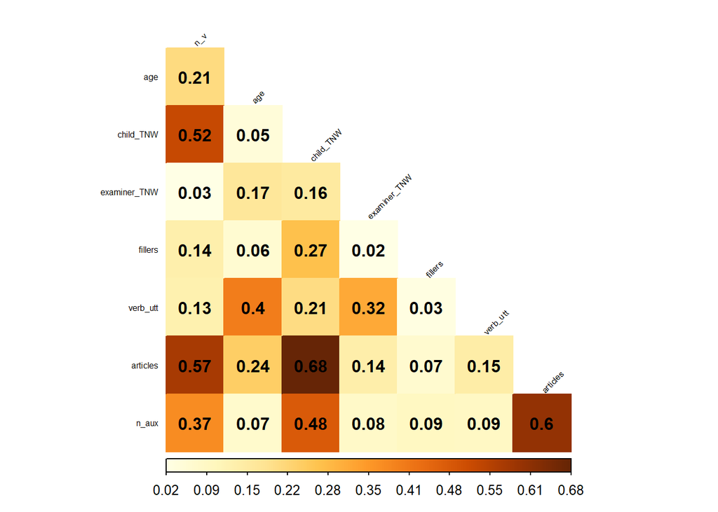

```r
corrplot(cor_matrix2,
         type="lower", #put color strength on bottom
         tl.pos = "ld", #Character or logical, position of text labels, 'ld'(default if type=='lower') means left and diagonal,
         tl.cex = 0.5, #Numeric, for the size of text label (variable names).
         method="color",
         addCoef.col="black",
         diag=FALSE,
         tl.col="black", #The color of text label.
         tl.srt=45, #Numeric, for text label string rotation in degrees, see text
         is.corr = FALSE, #if you include correlation matrix
         number.digits = 2) #number of digits after decimal
```

## *3. Cross-validated model with feature selection*

A machine learning approach was used to create a cross-validated model with feature selection using the 10 fold lm method using caret.

```r
set.seed(1234)

train.control <- trainControl(method = "cv", number = 10)
# cv = cross validated, 10 = 10 fold

machinemodel_1 <- train(n_v ~ ., data = model4_tib_sc,
                       method = "leapSeq", #stepwise selection
                       tuneGrid = data.frame(nvmax = 1:7),
                       trControl = train.control)

summary(machinemodel_1)
```

```
## Subset selection object
## 7 Variables  (and intercept)
##              Forced in Forced out
## age              FALSE      FALSE
## child_TNW        FALSE      FALSE
## examiner_TNW     FALSE      FALSE
## fillers          FALSE      FALSE
## verb_utt         FALSE      FALSE
## articles         FALSE      FALSE
## n_aux            FALSE      FALSE
## 1 subsets of each size up to 3
## Selection Algorithm: 'sequential replacement'
##          age child_TNW examiner_TNW fillers verb_utt articles n_aux
## 1  ( 1 ) " " " "       " "          " "     " "      "*"      " "
## 2  ( 1 ) " " "*"       " "          " "     " "      "*"      " "
## 3  ( 1 ) " " "*"       " "          " "     "*"      "*"      " "
```

```r
machinemodel_1$bestTune
```

```
##   nvmax
## 3     3
```

```r
#the three best variables of the machine learning models
machinemodel_1$results
```

```
##   nvmax      RMSE  Rsquared       MAE    RMSESD RsquaredSD      MAESD
## 1     1 0.7984933 0.3593908 0.5339848 0.2179456 0.09981218 0.07383054
## 2     2 0.7806393 0.3885407 0.5036341 0.2092745 0.10002867 0.07570583
## 3     3 0.7723327 0.4013707 0.5033488 0.2031345 0.09572958 0.07637088
## 4     4 0.8229530 0.3085132 0.5469592 0.1987833 0.07532727 0.07697304
## 5     5 0.7898535 0.3717194 0.5177030 0.2027060 0.08728689 0.08267959
## 6     6 0.7780596 0.3919778 0.5036242 0.2069467 0.09631577 0.07818236
## 7     7 0.7794808 0.3898816 0.5041700 0.2065369 0.09507088 0.07829387
```

```r
summary(machinemodel_1$finalModel)
```

```
## Subset selection object
## 7 Variables  (and intercept)
##              Forced in Forced out
## age              FALSE      FALSE
## child_TNW        FALSE      FALSE
## examiner_TNW     FALSE      FALSE
## fillers          FALSE      FALSE
## verb_utt         FALSE      FALSE
## articles         FALSE      FALSE
## n_aux            FALSE      FALSE
## 1 subsets of each size up to 3
## Selection Algorithm: 'sequential replacement'
##          age child_TNW examiner_TNW fillers verb_utt articles n_aux
## 1  ( 1 ) " " " "       " "          " "     " "      "*"      " "
## 2  ( 1 ) " " "*"       " "          " "     " "      "*"      " "
## 3  ( 1 ) " " "*"       " "          " "     "*"      "*"      " "
```

From the machine model, the coefficients can then be checked for suppression effects.

## *4. Suppression Effects*

The model was checked for suppression effects by looking at the correlations between the predictors and the outcome variable, number of verbs, to see if any negative correlations existed. Suppression effects were found in the predictor variable of verbal utterances.

```r
coef(machinemodel_1$finalModel, 3)
```

```
##   (Intercept)     child_TNW      verb_utt      articles
##  1.875670e-17  3.375253e-01 -1.516406e-01  3.187650e-01
```

## *5. Rerun the model if suppression effects exist and check for suppression effects again*

The variable of number of verbal utterances causing the suppression effect was removed and the new model was ran. Again, we checked for suppression effects. No suppression effects were found, and the significant predictors were identified (child total number of words, and number of articles)

```r
str(model4_tib_sc)
```

```
## tibble [1,163 × 8] (S3: tbl_df/tbl/data.frame)
##  $ n_v         : num [1:1163] -0.642 -0.642 -0.642 -0.157 -0.642 ...
##  $ age         : num [1:1163] 2 2.22 1.84 2.59 2.34 ...
##  $ child_TNW   : num [1:1163] -0.561 -0.2272 -0.6475 -0.0748 -0.5074 ...
##  $ examiner_TNW: num [1:1163] -0.306 0.444 -0.371 0.248 0.216 ...
##  $ fillers     : num [1:1163] 0.11 -0.795 -0.23 -0.569 -0.456 ...
##  $ verb_utt    : num [1:1163] -1.2785 -0.6141 0.7657 0.0843 -0.2087 ...
##  $ articles    : num [1:1163] -0.615 -0.615 -0.589 -0.615 -0.589 ...
##  $ n_aux       : num [1:1163] 0.148 0.794 -0.175 -0.498 -0.175 ...
```

```r
model4_tib_sc_2 <- model4_tib_sc[, c(1:5, 7:8)] # creates a new model that excludes verbal utterances (variable 6)

str(model4_tib_sc_2)
```

```
## tibble [1,163 × 7] (S3: tbl_df/tbl/data.frame)
##  $ n_v         : num [1:1163] -0.642 -0.642 -0.642 -0.157 -0.642 ...
##  $ age         : num [1:1163] 2 2.22 1.84 2.59 2.34 ...
##  $ child_TNW   : num [1:1163] -0.561 -0.2272 -0.6475 -0.0748 -0.5074 ...
##  $ examiner_TNW: num [1:1163] -0.306 0.444 -0.371 0.248 0.216 ...
##  $ fillers     : num [1:1163] 0.11 -0.795 -0.23 -0.569 -0.456 ...
##  $ articles    : num [1:1163] -0.615 -0.615 -0.589 -0.615 -0.589 ...
##  $ n_aux       : num [1:1163] 0.148 0.794 -0.175 -0.498 -0.175 ...
```

```r
machinemodel_2 <- train(n_v ~ ., data = model4_tib_sc_2,
                       method = "leapSeq", #stepwise selection
                       tuneGrid = data.frame(nvmax = 1:6),
                       trControl = train.control)

summary(machinemodel_2)
```

```
## Subset selection object
## 6 Variables  (and intercept)
##              Forced in Forced out
## age              FALSE      FALSE
## child_TNW        FALSE      FALSE
## examiner_TNW     FALSE      FALSE
## fillers          FALSE      FALSE
## articles         FALSE      FALSE
## n_aux            FALSE      FALSE
## 1 subsets of each size up to 2
## Selection Algorithm: 'sequential replacement'
##          age child_TNW examiner_TNW fillers articles n_aux
## 1  ( 1 ) " " " "       " "          " "     "*"      " "
## 2  ( 1 ) " " "*"       " "          " "     "*"      " "
```

```r
coef(machinemodel_2$finalModel2)
```

[output not shown]

```r
machinemodel_2$bestTune
```

```
##   nvmax
## 2     2
```

```r
#the three best variables of the machine learning models
machinemodel_2$results
```

```
##   nvmax      RMSE  Rsquared       MAE    RMSESD RsquaredSD      MAESD
## 1     1 0.8126410 0.3450548 0.5339970 0.1527004 0.08245118 0.05586654
## 2     2 0.7921263 0.3778311 0.5031893 0.1489672 0.07021098 0.05902757
## 3     3 0.8294821 0.3104067 0.5471185 0.1517232 0.05294576 0.05862251
## 4     4 0.8244547 0.3197699 0.5422555 0.1574005 0.05826462 0.06133442
## 5     5 0.7942020 0.3746392 0.5048517 0.1444321 0.07309570 0.05870585
## 6     6 0.7937105 0.3759935 0.5043146 0.1434343 0.07293784 0.05791317
```

```r
summary(machinemodel_2$finalModel)
```

```
## Subset selection object
## 6 Variables  (and intercept)
##              Forced in Forced out
## age              FALSE      FALSE
## child_TNW        FALSE      FALSE
## examiner_TNW     FALSE      FALSE
## fillers          FALSE      FALSE
## articles         FALSE      FALSE
## n_aux            FALSE      FALSE
## 1 subsets of each size up to 2
## Selection Algorithm: 'sequential replacement'
##          age child_TNW examiner_TNW fillers articles n_aux
## 1  ( 1 ) " " " "       " "          " "     "*"      " "
## 2  ( 1 ) " " "*"       " "          " "     "*"      " "
```

```r
coef(machinemodel_2$finalModel2)
```

[output not shown]

## *6. Producing the final model using cross-validation*

Using the machine learning approach with cross-validation and accounting for suppression effects, the second model produced contained only the significant predictors of child total number of words and number of articles.

```r
summary(machinemodel_2$finalModel)
```

```
## Subset selection object
## 6 Variables  (and intercept)
##              Forced in Forced out
## age              FALSE      FALSE
## child_TNW        FALSE      FALSE
## examiner_TNW     FALSE      FALSE
## fillers          FALSE      FALSE
## articles         FALSE      FALSE
## n_aux            FALSE      FALSE
## 1 subsets of each size up to 2
## Selection Algorithm: 'sequential replacement'
##          age child_TNW examiner_TNW fillers articles n_aux
## 1  ( 1 ) " " " "       " "          " "     "*"      " "
## 2  ( 1 ) " " "*"       " "          " "     "*"      " "
```

## *7. Produce the final model without cross-validation to get statistical information*

A final model without cross-validation was written for the linear model to produce the statistical metrics.

The t value for child total number of words was 7.92 (p < .05), and the t value for articles was 12.50 (p < .05). The F statistic was 323.9.

```r
finalmodel <- lm(n_v ~ child_TNW + articles, data = model4_tib_sc_2)

summary(finalmodel)
```

```
##
## Call:
## lm(formula = n_v ~ child_TNW + articles, data = model4_tib_sc_2)
##
## Residuals:
##     Min      1Q  Median      3Q     Max
## -2.9150 -0.3487 -0.1574  0.2266  6.5484
##
## Coefficients:
##              Estimate Std. Error t value Pr(>|t|)
## (Intercept) 2.610e-15  2.351e-02   0.000        1
## child_TNW   2.524e-01  3.189e-02   7.916 5.69e-15 ***
## articles    3.985e-01  3.189e-02  12.496  < 2e-16 ***
## ---
## Signif. codes:  0 '***' 0.001 '**' 0.01 '*' 0.05 '.' 0.1 ' ' 1
##
## Residual standard error: 0.8017 on 1160 degrees of freedom
## Multiple R-squared:  0.3584, Adjusted R-squared:  0.3572
## F-statistic: 323.9 on 2 and 1160 DF,  p-value: < 2.2e-16
```

## *8. Visualize using a scatter plot*

The final model was visualized by creating a scatter plot.

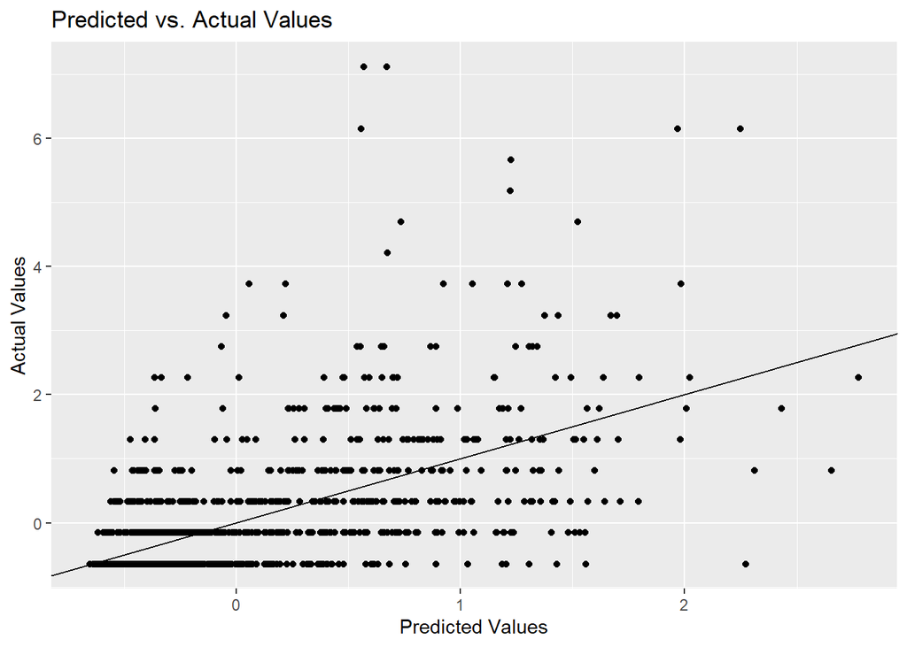

```r
ggplot(model4_tib_sc_2, aes(x=predict(finalmodel), y= model4_tib_sc_2$n_v)) +
  geom_point() +
  geom_abline(intercept=0, slope=1) +
  labs(x='Predicted Values', y='Actual Values', title='Predicted vs. Actual Values')
```

# **Discussion**

Existing data sets that do not contain the number of verbs but do contain the child total number of words and number of articles could be evaluated for potential increases in the number of verbs by looking at the child total number of words and number of articles. Future research should consider exploring logistic regression on the outcome variable of a diagnosis of SLI to see what available metrics most predict SLI. Other measures of linguistic growth not available in this data set, such as the number of unique subjects, number of unique verbs, and number of unique subject-verb combinations should be compared to current measures of linguistic growth (e.g., MLU and NDW) to see if they are better predictors of linguistic growth (Hadley, 2020; Kaiser et al., in prep.).

# **References**

1. Curtis, P. R., Roberts, M. Y., Estabrook, R., & Kaiser, A. P. (2017). The longitudinal effects of early language intervention on Children’s Problem Behaviors. *Child Development*, *90*(2), 576-592.
2. D. Wetherell, N. Botting, and G. Conti-Ramsden. (2007). Narrative skills in adolescents with a history of SLI in relation to non-verbal IQ scores. *Child Language Teaching and Therapy*, *23*(1), 95–113.
3. Ervin, M. (2001). SLI: what we know and why it matters. *American Speech and Hearing Association*, *6*(12).
4. Hadley, P. (2020). Exploring sentence diversity at the boundary of typical and impaired language abilities. *Journal of Speech, Language, and Hearing Research*, 63, 3236-3251.
5. Hadley, P., McKenna, M., & Rispoli, M. (2018). Sentence diversity in early language development: R*ecommendations for target selection and progress monitoring.*
6. *American Journal of Speech-Language Pathology*, 27, 553-565.
7. Hampton, L. H., Kaiser, A. P., & Roberts, M. R. (2017). One-year language outcomes in toddlers with language delays: An RCT follow-up. *Pediatrics*, *140*(5).
8. Kaiser, A., Roberts, M, & Hadley, P. (In Preparation). *Maximizing outcomes for preschoolers with developmental language disorder: Testing the effects of a sequentially targeted naturalistic intervention.*
9. National Institute of Health, Deafness and Other Communication Disorders. NIDCD Fact Sheet: Voice Speech and Language, Specific Language Impairment. U.S. Department of Health and Human Services.
10. Roberts, M., & Kaiser, A. (2012). Assessing the effects of a parent-implemented language intervention for children with language impairments using empirical benchmarks: A pilot study. *Journal of Speech, Language, and Hearing Research*, *55*(6), 1655-1670.
11. Rice, M. L., Hadley, P. A., & Alexander, A. (1993). Social biases toward children with specific language impairment: A correlative causal model of language limitations. *Applied Psycholinguistics*, 14, 445-471.

    RStudio Team (2020). RStudio: Integrated Development for R. RStudio, PBC, Boston, MA URL http://www.rstudio.com/.
12. Schneider, D., Hayward, D., Dub, R. V. (2006). Storytelling from pictures using the Edmonton Narrative Norms Instrument.
13. Gillam, R., Pearson, N. (2004).Test of Narrative Language. Austin, TX: Pro-Ed Inc.

```